Fernando A. B. Sabino da Silva - UFRGS

Este trabalho tem como objetivo colocar em prática os modelos de séries temporais univariadas **AR(p)**, **MA(q)**, **ARMA(p,q)**, **ARCH(m)** e **GARCH(m,n)** em uma série temporal de retornos de um ativo financeiro.

Suponha que $r_{t}$ é o logaritmo do retorno de um ativo financeiro em $t$ e que $\left\{r_{t}\right\}_{t=1}^{T}$ é a série temporal do logaritmo de $T$ retornos. Como sabemos, para modelar tal série temporal, temos duas equações que precisam ser estimadas: a média condicional e a variância condicional. Para a equação da média condicional, podemos assumir um modelo $ARMA(p,q)$, neste formato:

$$\begin{aligned}
&&& r_{t} = \mu_{t} + a_{t} \\
&&& \mu_{t} = \phi_{0} + \sum_{i=1}^{p}{\phi_{i}r_{t-i}} + \sum_{j=1}^{q}{\theta_{j}a_{t-j}}
\end{aligned}$$

Já para a variância condicional, temos a equação abaixo:

$$\begin{aligned}
&&& a_{t}=\sigma_t\epsilon_t \\
&&& \sigma_{t}^{2} = \alpha_{0} + \sum_{i=1}^{m}{}\alpha_{i}a_{t-i}^{2}+\sum_{j=1}^{n}{\beta_j\sigma^{2}_{t-j}}
\end{aligned}$$

onde, $\left\{\epsilon_t \right\}_{t=1}^{t}$ é uma sequência de variáveis aleatórias independente e identicamente distribuídas (iid) com média $0$ e variância $1$, $\alpha_{0}>0$, $\alpha_{i}\geq 0$, $\beta_{j}\geq 0$ para $i>0$ e $j>0$. Além disso, $\sum_{i=1}^{max(m,n)}{(\alpha_i+\beta_i)<1}$ que garante que a variância incondicional de $a_t$ é finita. Podemos assumir que $\epsilon_t$ segue uma distribuição Normal, t-Student ou outra de interesse. Em algumas aplicações, podemos usar também distribuições assimétricas para $\epsilon_t$. Observe que se $n=0$ a equação da variância condicional se comporta como um modelo $ARCH(m)$.

##### **PROCESSO DE ANÁLISE**

1. Especificar a equação para a média condicional ($\mu_{t}$):
   - Visualizar os dados e identificar observações fora do padrão (*outliers* ou dados faltantes) e eliminá-las.
   - Se necessário, transformar os dados para estabilizar a variância (logaritmo dos dados, variação ou retorno, por exemplo)
   - Testar se os dados são estacionários. Caso tenha raiz unitária é preciso diferenciar os dados até se tornarem estacionários. Para isso, testa-se novamente se a série diferenciada se tornou estacionária.
   - Examinar as funções de autocorrelação (FAC) e autocorrelação parcial (FACP) para determinar as ordens máximas $P$ e $Q$ para os componentes AR e MA da série estacionária (diferenciada, se necessário).
   - Estimar todas as combinações para $p$, $d$ e $q$. Aqui, $d$ será fixo e igual ao número de vezes necessárias para tornar a série original estacionáira. Se não foi preciso diferenciar a série, $d=0$.
   - Escolher dentre todos os modelos estimados no passo anterior, o modelo com menor AIC e/ou BIC.
   - Examinar se os resíduos se comportam como um ruído branco:
     - Testar autocorrelação nos resíduos: visualizar a função de autocorrelação (FAC) dos resíduos. Se existem defasagens estatisticamente significante (acima da linha pontilhada), há autocorrelação serial.
     - Testar heterocedasticidade condicional: visualizar a função de autocorrelação (FAC) dos resíduos ao quadrado. Se existem defasagens estatisticamente significante (acima da linha pontilhada), há heterocedasticidade condicional. Outra alternativa é o teste LM de Engle (1982).
     - Verificar a distribuição de probabilidade assumida no processo de estimação: realizar teste que verifique se os resíduos se comportam de acordo com a distribuição de probabilidade adotada.
   - Se os resíduos são bem comportados (ruído branco), **obter as previsões apenas com a estimação da média condicional**. Caso contrário, revisar os passos anteriores para certificar que foram realizados corretamente. Se mesmo assim existir heterocedasticidade condicional e a distribuição de probabilidade não condiz com a hipótese assumida (geralmente uma distribuição Normal), **avançar para o próximo passo e estimar a variância condicional também**.
2. Especificar um modelo de volatilidade e estimar **conjuntamente** as equações da média e variância condicional:
   - Examinar as funções de autocorrelação (FAC) e autocorrelação parcial (FACP) dos resíduos ao quadrado **(obtidos da estimação da média condicional)** para determinar as ordens máximas $M$ e $N$ para os componentes ARCH e GARCH, respectivamente.
   - Examinar o histograma dos resíduos juntamente com a densidade das distribuições Normal e t-Student para determinar qual a melhor distribuição se ajusta aos dados. Outras distribuições de probabilidade também podem ser usadas, tal como a Cauchy. Além disso, você pode usar a versão assimétrica destas distribuições caso perceba assimetria no histograma dos resíduos.
   - Estimar todas as combinações para $m=1,..,M$ e $n=0,...,N$ para a variância condicional juntamente com a especificação ARMA(p,q) escolhida no passo 1
   - Escolher o modelo com menor AIC e/ou BIC
3. Verificar o modelo estimado
   - Avaliar o gráfico da função de autocorrelação do quadrado dos resíduos padronizados estimados no passo 2. O ideal é que as defasagens não ultrapassem a linha pontilhada.
   - Avaliar se as restrições impostas sobre os parâmetros são atendidas
   - Testar se os resíduos padronizados se comportam conforme a hipóte de distribuição de probabilidade assumida no passo 2 no momento de estimar conjuntamente a média condicional e a variância condicional.
4. Visualizar os resultados
   - Gráfico da volatilidade condicional

##### **RESULTADOS**

A ação `PETR3.SA` da Petrobras Brasileiro S.A. negociada na BMFBOVESPA foi escolhida e o período de análise é de 02-01-2015 até 12-11-2019. Seguindo o processo proposto, temos os seguintes resultados:

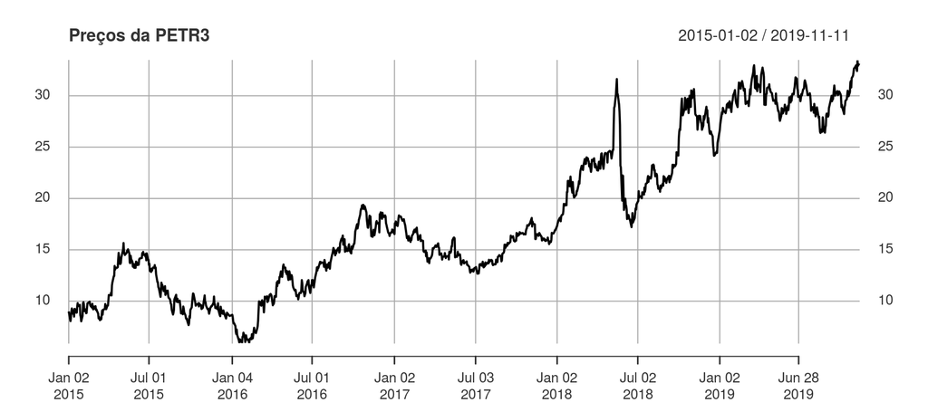

- Como sabemos, os retornos financeiros raramente apresentam tendência ou sazonalidade, com exceção eventualmente de retornos intradiários que não é o caso da série temporal em análise. Além disso, a série temporal de retornos é estacionária dado que na maioria das vezes os retornos oscilam entre $-1$ e $1$. Em função dessas características, optamos por usar a série temporal dos retornos da `PETR3.SA` que permitirá estabilizar a variância dos dados e diminuir a chance de existência de raíz unitária. O gráfico abaixo mostra a série temporal dos retornos da `PETR3.SA`:

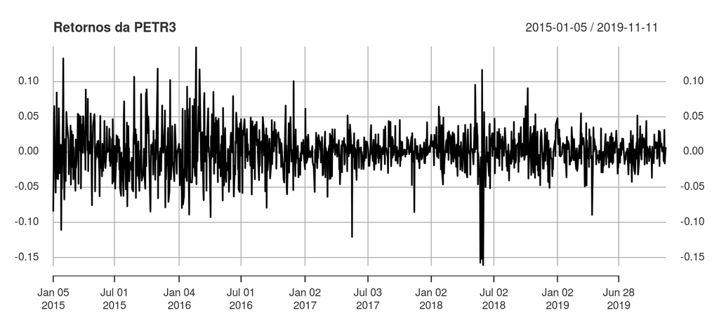

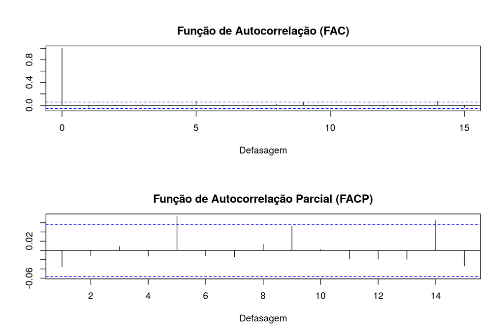

$$\begin{aligned}
&&& r_{t} = \mu_{t} + a_{t} \\
&&& \mu_{t} = \phi_{0}
\end{aligned}$$

- Examinar se os resíduos se comportam como um ruído branco:

No processo de definição do modelo $ARMA(p,q)$ assumimos que o termo de erro $a_t$ não é autocorrelacionado, ou seja, $E\left[ \left(a_t-\bar{a}\right)\left(a_{t-1}-\bar{a}\right)\right]=E[a_{t}a_{t-1}]=0$. Como teste para verificar a validade de tal hipótese, temos abaixo o gráfico da função de autocorrelação (FAC) dos resíduos (nossa estimativa para o termo de erro) e encontramos que não há presença de autocorrelação serial dado que a grande maioria das defasagens não são estatisticamente significantes.

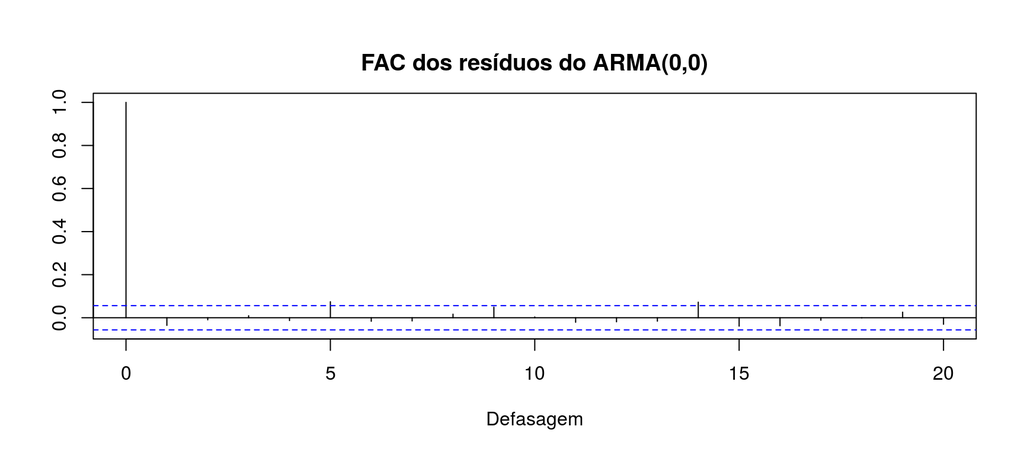

Porém, quando avaliamos o gráfico da função de autocorrelação (FAC) do quadrado dos resíduos abaixo, observamos que existem defasagens estatisticamente significante (acima da linha pontilhada). Isso confirma a presença de heterocedasticidade condicional assim como um teste LM de Engle (1982) caso realizado.

Isso não condiz com a hipótese assumida na definição do modelo $ARMA(p,q)$ de que a variância do termo de erro é contante e independente do tempo, ou seja, que $Var(a_t) = \sigma_{a}^{2}$.

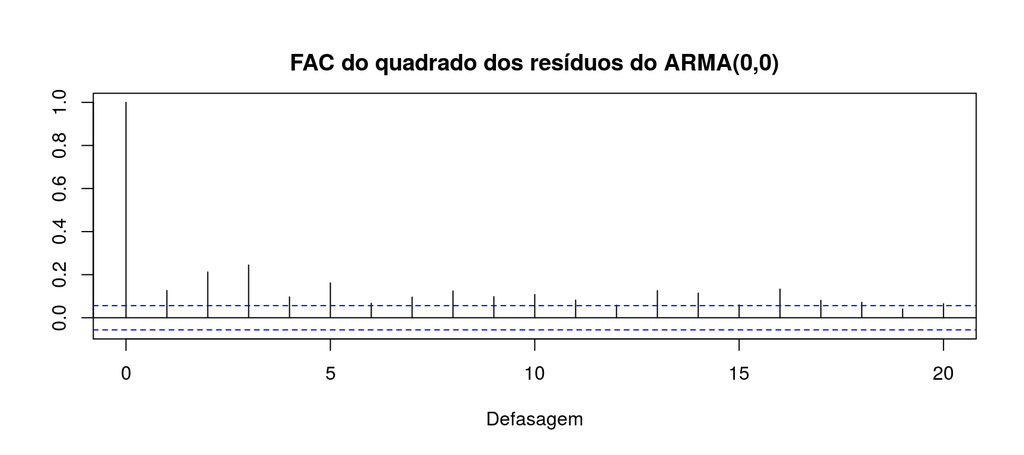

A presençca de [fatos estilizados](https://rpubs.com/hudsonchavs/timeseries1) em séries temporais financeiros (como o retorno de um ativo financeiro) gera tais inconsistências, principalmente a presença de heterocedasticidade condicional. Desta forma, não podemos assumir que apenas a estimação da equação da média condicional é o suficiente para a série da `PETR3.SA` e precisamos estimar a variância condicional também.

2. Especificar um modelo de volatilidade e estimar **conjuntamente** as equações da média e variância condicional:
- Precisamos examinar as funções de autocorrelação (FAC) e autocorrelação parcial (FACP) dos resíduos ao quadrado **(obtidos da estimação da média condicional)** para determinar as ordens máximas $M$ e $N$ para os componentes ARCH e GARCH, respectivamente. Como resultado, temos abaixo tais gráficos e optamos por $M=3$ e $N=5$ (não faz sentido escolher N muito grande).

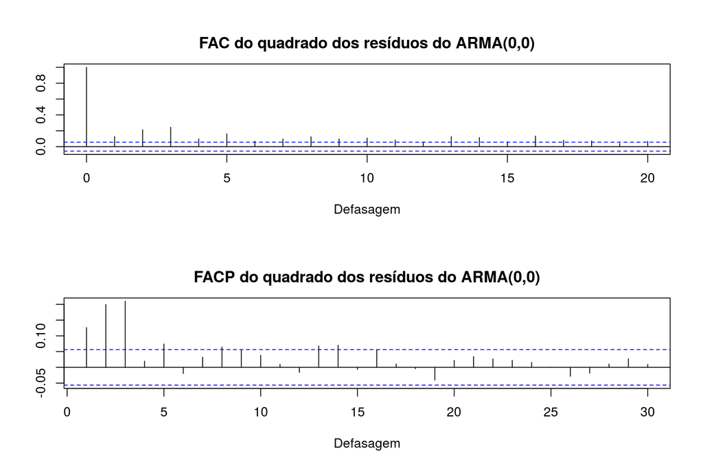

- Antes de executarmos a estimação em conjunto das equações para a média condicional e variância condicional, precisamos examinar o histograma dos resíduos juntamente com a densidade das distribuições Normal e t-Student para determinar qual a melhor distribuição se ajusta aos dados. Como resultado temos o gráfico abaixo e percebemos que a distribuição t-Student se adequa melhor aos dados e será usada no processo de estimação pelo método de máxima verossimilhança.

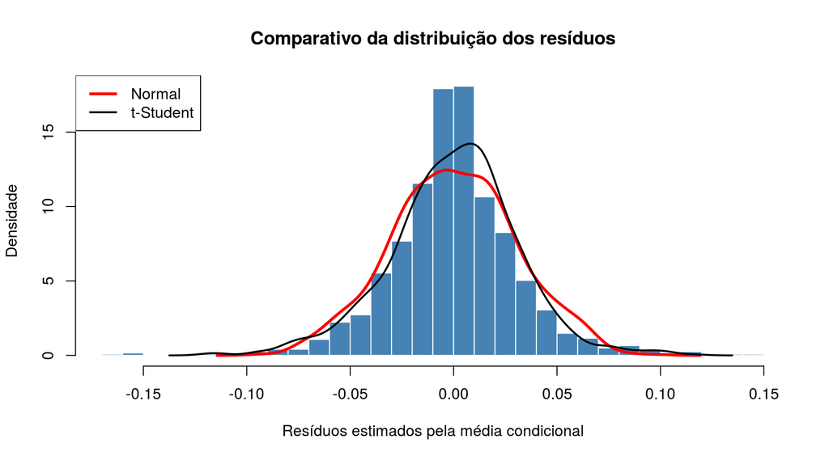

3. Verificar o modelo estimado
- Uma vez definido o modelo, precisamos avaliar se ele continua com heterocedasticidade condicional. Se nosso modelo realmente controlou a heterocedasticidade condicional, não deveríamos ter defasagens no gráfico da FAC dos resíduos ao quadrado ultrapassando a linha pontilhada. O gráfico abaixo confima que não há heterocedasticidade condicional nos resíduos do modelo $ARMA(0,0)-GARCH(1,1)$.

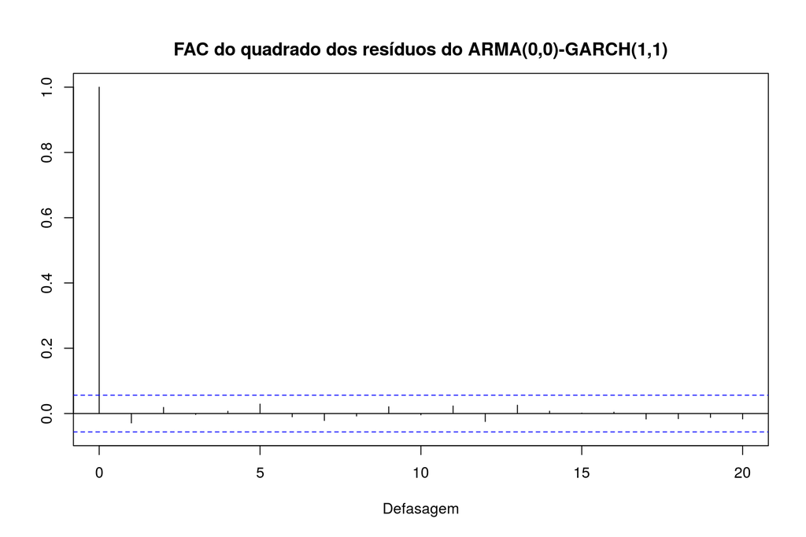

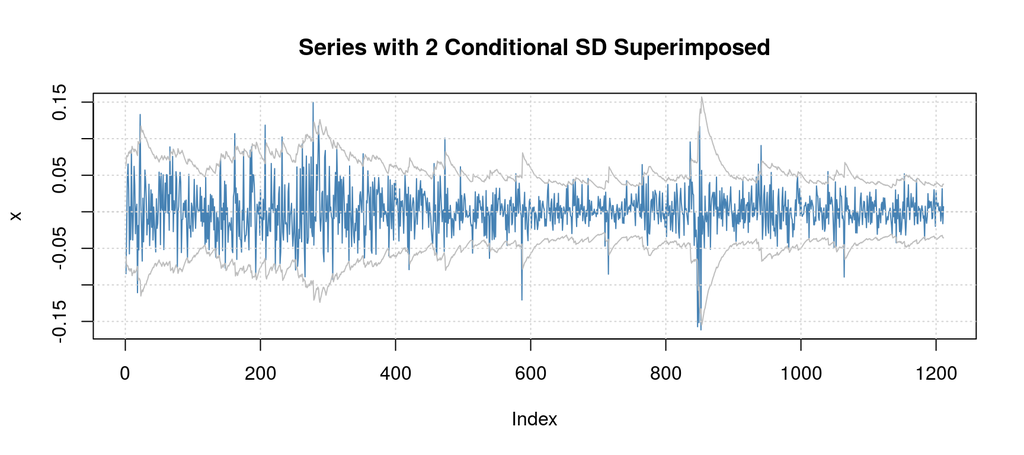

##### **REFERÊNCIAS**

Dickey, David A, and Wayne A Fuller. 1979. “Distribution of the Estimators for Autoregressive Time Series with a Unit Root” 74 (366a). Journal of the American statistical association: 427–31.

Engle, Robert F. 1982. “Autoregressive Conditional Heteroscedasticity with Estimates of the Variance of United Kingdom Inflation.” Econometrica Journal of the Econometric Society.